# Food Swamp Analysis

I chose cardiovascular disease deaths instead of BMI as dependent variable. Gini index is a measure of residential stratification commonly utilizd by the U.S. Census Bureau.

```r
CVD_df <- read_csv("Total CVD Deaths 15-17.csv",
                   col_types = cols(display_name = col_skip(),
                  theme_range = col_skip()))

Gini_Index <- read_csv("Gini Index.csv",
                       col_types = cols(County = col_skip(),
                      State = col_skip()), skip = 1)

access <- read_excel("Food Atlas Data.xls","ACCESS") %>%
                    select(c("FIPS","State","County","LACCESS_LOWI15","PCT_LACCESS_LOWI15"))

stores <- read_excel("Food Atlas Data.xls","STORES") %>%
                    select(c("FIPS","GROC14","SUPERC14","CONVS14","SPECS14"))

restaurants <- read_excel("Food Atlas Data.xls","RESTAURANTS") %>%
                          select(c("FIPS","FFR14"))

SNAP <- read_excel("Food Atlas Data.xls","ASSISTANCE") %>%
                  select(c("FIPS","PCT_SNAP16"))

markets <- read_excel("Food Atlas Data.xls","LOCAL") %>%
                      select(c("FIPS","FMRKT16"))

milk_soda <- read_excel("Food Atlas Data.xls","PRICES_TAXES") %>%
                        select(c("FIPS","MILK_SODA_PRICE10"))

socioeconomic <- read_excel("Food Atlas Data.xls", "SOCIOECONOMIC") %>%
                            select(c("FIPS","PCT_NHWHITE10","PCT_NHBLACK10",
                                     "PCT_HISP10","PCT_NHASIAN10","PCT_NHNA10","PCT_NHPI10",
                                     "PCT_65OLDER10","PCT_18YOUNGER10","MEDHHINC15"))
```

I did multiple joins to create data frame, but would be interested in seeing if there is a more efficient way. Maybe an option that includes piping so there are no intermediates.

I also added the calculated food swamp variables and added them to the data frame. Initially I was focused on removing all Puerto Rico values since there was no data for the variables, but there were also counties with little info. So I removed the Na's so that it would not throw errors in later analysis. I also replaced any infinite values from in the calculated variables with Na so The sample data frame went from ~3200 to ~3000 counties.

##Data Preparation

```r
INT1 <- full_join(access,markets, by = "FIPS")
INT2 <- full_join(INT1,stores, by = "FIPS")
INT3 <- full_join(INT2,restaurants, by = "FIPS")
INT4 <- full_join(INT3,CVD_df, by= c("FIPS"="cnty_fips"))
INT5 <- full_join(INT4,milk_soda, by = "FIPS")
INT6 <- full_join(INT5,SNAP, by = "FIPS")
INT7 <- full_join(INT6,Gini_Index, by = c("FIPS"="id"))
FINAL_df <- full_join(INT7,socioeconomic, by = "FIPS")


FINAL_df <- mutate(FINAL_df, RFEI = (FINAL_df$FFR14+FINAL_df$CONVS14)/(FINAL_df$GROC14))
FINAL_df<- mutate(FINAL_df, Exp_RFEI_1 = (FINAL_df$CONVS14 + FINAL_df$SUPERC14 + FINAL_df$FFR14)/(FINAL_df$GROC14 + FINAL_df$FMRKT16 + FINAL_df$SPECS14))
FINAL_df<- mutate(FINAL_df, Exp_RFEI_2 = (FINAL_df$CONVS14 + FINAL_df$FFR14)/(FINAL_df$GROC14 + FINAL_df$FMRKT16 + FINAL_df$SPECS14 + FINAL_df$SUPERC14))

FINAL_df <- rename(FINAL_df, c("Low_Access"="LACCESS_LOWI15","Low Access_PCT"="PCT_LACCESS_LOWI15","Farmers"="FMRKT16","Grocery"="GROC14","Supercenter"="SUPERC14","Convenience"="CONVS14","Specialty"="SPECS14","Fast_Food"="FFR14","CVD"="Value","Milk_Soda"="MILK_SODA_PRICE10","SNAP_PCT"="PCT_SNAP16","Gini_Index"="Estimate!!Gini Index","Gini_Index_Margin"="Margin of Error!!Gini Index","WHITE_PCT"="PCT_NHWHITE10","BLACK_PCT"="PCT_NHBLACK10","HISPANIC_PCT"="PCT_HISP10","ASIAN_PCT"="PCT_NHASIAN10","Native_PCT"="PCT_NHNA10","Pacific_PCT"="PCT_NHPI10","65Older_PCT"="PCT_65OLDER10","18Younger_PCT"="PCT_18YOUNGER10","Median_Income"="MEDHHINC15"))

FINAL_df <- na.omit(FINAL_df)

missing <- FINAL_df[!complete.cases(FINAL_df),]

FINAL_df[] <- lapply(FINAL_df, function(x) replace(x, is.infinite(x), NA))
```

I had to clean the environment of all the intermediates. It was driving me insane! I only deleted the intermediates once I confirmed the data was accurately added to the main data frame.

##Analysis

```r
summary(FINAL_df) %>% kable(caption = "Descriptive Statistics") %>% kable_styling(bootstrap_options = c("striped", "hover", "responsive", font_size = 10, fixed_thead= T)) %>% scroll_box(width = "100%", height = "400px")
```

Descriptive Statistics

|  | FIPS | State | County | Low_Access | Low Access_PCT | Farmers | Grocery | Supercenter | Convenience | Specialty | Fast_Food | CVD | Milk_Soda | SNAP_PCT | Gini_Index | Gini_Index_Margin | WHITE_PCT | BLACK_PCT | HISPANIC_PCT | ASIAN_PCT | Native_PCT | Pacific_PCT | 65Older_PCT | 18Younger_PCT | Median_Income | RFEI | Exp_RFEI_1 | Exp_RFEI_2 |
| --- | --- | --- | --- | --- | --- | --- | --- | --- | --- | --- | --- | --- | --- | --- | --- | --- | --- | --- | --- | --- | --- | --- | --- | --- | --- | --- | --- | --- |
|  | Length:3080 | Length:3080 | Length:3080 | Min. : 0.0 | Min. : 0.000 | Min. : 0.000 | Min. : 0.00 | Min. : 0.000 | Min. : 0.00 | Min. : 0.000 | Min. : 0.0 | Min. : 93.8 | Min. :0.6372 | Min. : 5.818 | Min. :0.3290 | Min. :0.00140 | Min. : 2.86 | Min. : 0.0000 | Min. : 0.1311 | Min. : 0.0000 | Min. : 0.0000 | Min. :0.00000 | Min. : 3.728 | Min. : 9.112 | Min. : 22894 | Min. : 0.000 | Min. : 0.000 | Min. : 0.000 |
|  | Class :character | Class :character | Class :character | 1st Qu.: 612.9 | 1st Qu.: 3.590 | 1st Qu.: 0.000 | 1st Qu.: 3.00 | 1st Qu.: 0.000 | 1st Qu.: 7.00 | 1st Qu.: 0.000 | 1st Qu.: 5.0 | 1st Qu.: 396.1 | 1st Qu.:0.8230 | 1st Qu.:10.962 | 1st Qu.:0.4197 | 1st Qu.:0.01360 | 1st Qu.:67.28 | 1st Qu.: 0.4096 | 1st Qu.: 1.5946 | 1st Qu.: 0.2704 | 1st Qu.: 0.1948 | 1st Qu.:0.01007 | 1st Qu.:13.196 | 1st Qu.:21.430 | 1st Qu.: 40345 | 1st Qu.: 3.955 | 1st Qu.: 2.667 | 1st Qu.: 2.500 |
|  | Mode :character | Mode :character | Mode :character | Median : 1649.8 | Median : 6.490 | Median : 1.000 | Median : 5.00 | Median : 1.000 | Median : 16.00 | Median : 1.000 | Median : 15.0 | Median : 454.4 | Median :0.8450 | Median :13.647 | Median :0.4411 | Median :0.02050 | Median :85.91 | Median : 1.9580 | Median : 3.2861 | Median : 0.4628 | Median : 0.3036 | Median :0.02272 | Median :15.606 | Median :23.316 | Median : 46694 | Median : 5.868 | Median : 4.000 | Median : 3.621 |
|  | NA | NA | NA | Mean : 5860.4 | Mean : 8.461 | Mean : 2.739 | Mean : 21.22 | Mean : 1.709 | Mean : 40.27 | Mean : 7.265 | Mean : 73.6 | Mean : 466.2 | Mean :0.9102 | Mean :13.364 | Mean :0.4432 | Mean :0.02317 | Mean :78.62 | Mean : 8.8439 | Mean : 8.3406 | Mean : 1.0651 | Mean : 1.5700 | Mean :0.04938 | Mean :15.953 | Mean :23.412 | Mean : 48438 | Mean : 6.496 | Mean : 4.419 | Mean : 3.977 |
|  | NA | NA | NA | 3rd Qu.: 4869.2 | 3rd Qu.:10.582 | 3rd Qu.: 3.000 | 3rd Qu.: 12.00 | 3rd Qu.: 1.000 | 3rd Qu.: 36.00 | 3rd Qu.: 4.000 | 3rd Qu.: 45.0 | 3rd Qu.: 522.1 | 3rd Qu.:1.0400 | 3rd Qu.:15.467 | 3rd Qu.:0.4639 | 3rd Qu.:0.02942 | 3rd Qu.:94.21 | 3rd Qu.:10.0304 | 3rd Qu.: 8.2912 | 3rd Qu.: 0.9691 | 3rd Qu.: 0.6133 | 3rd Qu.:0.04555 | 3rd Qu.:18.261 | 3rd Qu.:25.089 | 3rd Qu.: 54003 | 3rd Qu.: 8.188 | 3rd Qu.: 5.578 | 3rd Qu.: 5.000 |
|  | NA | NA | NA | Max. :259479.5 | Max. :71.844 | Max. :125.000 | Max. :2429.00 | Max. :95.000 | Max. :2111.00 | Max. :782.000 | Max. :7798.0 | Max. :1028.0 | Max. :1.2428 | Max. :22.764 | Max. :0.6237 | Max. :0.14800 | Max. :98.91 | Max. :85.4388 | Max. :95.7448 | Max. :32.9966 | Max. :86.3192 | Max. :2.01906 | Max. :43.385 | Max. :40.127 | Max. :125900 | Max. :43.000 | Max. :25.000 | Max. :26.000 |
|  | NA | NA | NA | NA | NA | NA | NA | NA | NA | NA | NA | NA | NA | NA | NA | NA | NA | NA | NA | NA | NA | NA | NA | NA | NA | NA’s :57 | NA’s :45 | NA’s :43 |

```r
m_1 <- lm(CVD ~ RFEI + Low_Access + Gini_Index + Median_Income, data=train)
summary(m_1)
```

```
##
## Call:
## lm(formula = CVD ~ RFEI + Low_Access + Gini_Index + Median_Income,
##     data = train)
##
## Residuals:
##     Min      1Q  Median      3Q     Max
## -279.45  -50.85   -6.48   45.72  472.32
##
## Coefficients:
##                 Estimate Std. Error t value Pr(>|t|)
## (Intercept)    5.261e+02  2.820e+01  18.655  < 2e-16 ***
## RFEI           4.570e+00  4.299e-01  10.631  < 2e-16 ***
## Low_Access    -5.081e-04  1.254e-04  -4.052 5.27e-05 ***
## Gini_Index     2.660e+02  5.547e+01   4.795 1.74e-06 ***
## Median_Income -4.190e-03  1.558e-04 -26.902  < 2e-16 ***
## ---
## Signif. codes:  0 '***' 0.001 '**' 0.01 '*' 0.05 '.' 0.1 ' ' 1
##
## Residual standard error: 80.32 on 2109 degrees of freedom
##   (42 observations deleted due to missingness)
## Multiple R-squared:  0.3495, Adjusted R-squared:  0.3482
## F-statistic: 283.3 on 4 and 2109 DF,  p-value: < 2.2e-16
```

```r
m_2 <- lm(CVD ~ Exp_RFEI_1 + Low_Access + Gini_Index + Median_Income, data=train)
summary(m_2)
```

```
##
## Call:
## lm(formula = CVD ~ Exp_RFEI_1 + Low_Access + Gini_Index + Median_Income,
##     data = train)
##
## Residuals:
##     Min      1Q  Median      3Q     Max
## -269.99  -51.15   -5.15   43.88  461.79
##
## Coefficients:
##                 Estimate Std. Error t value Pr(>|t|)
## (Intercept)    5.191e+02  2.749e+01  18.881  < 2e-16 ***
## Exp_RFEI_1     9.472e+00  6.480e-01  14.618  < 2e-16 ***
## Low_Access    -5.409e-04  1.228e-04  -4.405 1.11e-05 ***
## Gini_Index     2.380e+02  5.404e+01   4.404 1.11e-05 ***
## Median_Income -4.036e-03  1.523e-04 -26.496  < 2e-16 ***
## ---
## Signif. codes:  0 '***' 0.001 '**' 0.01 '*' 0.05 '.' 0.1 ' ' 1
##
## Residual standard error: 78.65 on 2119 degrees of freedom
##   (32 observations deleted due to missingness)
## Multiple R-squared:  0.3758, Adjusted R-squared:  0.3746
## F-statistic: 318.9 on 4 and 2119 DF,  p-value: < 2.2e-16
```

```r
m_3 <- lm(CVD ~ Exp_RFEI_2 + Low_Access + Gini_Index + Median_Income, data=train)
summary(m_3)
```

```
##
## Call:
## lm(formula = CVD ~ Exp_RFEI_2 + Low_Access + Gini_Index + Median_Income,
##     data = train)
##
## Residuals:
##     Min      1Q  Median      3Q     Max
## -275.50  -51.47   -6.37   44.28  471.50
##
## Coefficients:
##                 Estimate Std. Error t value Pr(>|t|)
## (Intercept)    5.201e+02  2.767e+01  18.799  < 2e-16 ***
## Exp_RFEI_2     1.035e+01  7.663e-01  13.508  < 2e-16 ***
## Low_Access    -5.300e-04  1.236e-04  -4.288 1.88e-05 ***
## Gini_Index     2.391e+02  5.438e+01   4.396 1.16e-05 ***
## Median_Income -4.053e-03  1.533e-04 -26.438  < 2e-16 ***
## ---
## Signif. codes:  0 '***' 0.001 '**' 0.01 '*' 0.05 '.' 0.1 ' ' 1
##
## Residual standard error: 79.17 on 2120 degrees of freedom
##   (31 observations deleted due to missingness)
## Multiple R-squared:  0.3673, Adjusted R-squared:  0.3661
## F-statistic: 307.6 on 4 and 2120 DF,  p-value: < 2.2e-16
```

```r
m_4 <- lm(CVD ~ RFEI + Low_Access + Gini_Index + Median_Income + SNAP_PCT, data = train)
summary(m_4)
```

```
##
## Call:
## lm(formula = CVD ~ RFEI + Low_Access + Gini_Index + Median_Income +
##     SNAP_PCT, data = train)
##
## Residuals:
##     Min      1Q  Median      3Q     Max
## -315.44  -48.41   -4.53   42.74  444.11
##
## Coefficients:
##                 Estimate Std. Error t value Pr(>|t|)
## (Intercept)    4.614e+02  2.777e+01  16.617  < 2e-16 ***
## RFEI           3.571e+00  4.234e-01   8.434  < 2e-16 ***
## Low_Access    -6.009e-04  1.214e-04  -4.948 8.09e-07 ***
## Gini_Index     1.476e+02  5.448e+01   2.710  0.00679 **
## Median_Income -3.616e-03  1.577e-04 -22.929  < 2e-16 ***
## SNAP_PCT       7.212e+00  5.891e-01  12.244  < 2e-16 ***
## ---
## Signif. codes:  0 '***' 0.001 '**' 0.01 '*' 0.05 '.' 0.1 ' ' 1
##
## Residual standard error: 77.63 on 2108 degrees of freedom
##   (42 observations deleted due to missingness)
## Multiple R-squared:  0.3927, Adjusted R-squared:  0.3912
## F-statistic: 272.6 on 5 and 2108 DF,  p-value: < 2.2e-16
```

```r
m_5 <- lm(CVD ~ Exp_RFEI_1 + Low_Access + Gini_Index + Median_Income + SNAP_PCT, data = train)
summary(m_5)
```

```
##
## Call:
## lm(formula = CVD ~ Exp_RFEI_1 + Low_Access + Gini_Index + Median_Income +
##     SNAP_PCT, data = train)
##
## Residuals:
##     Min      1Q  Median      3Q     Max
## -298.27  -49.39   -4.41   41.15  437.77
##
## Coefficients:
##                 Estimate Std. Error t value Pr(>|t|)
## (Intercept)    4.621e+02  2.719e+01  16.997  < 2e-16 ***
## Exp_RFEI_1     7.743e+00  6.481e-01  11.948  < 2e-16 ***
## Low_Access    -6.213e-04  1.195e-04  -5.198  2.2e-07 ***
## Gini_Index     1.331e+02  5.333e+01   2.496   0.0127 *
## Median_Income -3.545e-03  1.543e-04 -22.969  < 2e-16 ***
## SNAP_PCT       6.570e+00  5.838e-01  11.253  < 2e-16 ***
## ---
## Signif. codes:  0 '***' 0.001 '**' 0.01 '*' 0.05 '.' 0.1 ' ' 1
##
## Residual standard error: 76.41 on 2118 degrees of freedom
##   (32 observations deleted due to missingness)
## Multiple R-squared:  0.411,  Adjusted R-squared:  0.4096
## F-statistic: 295.6 on 5 and 2118 DF,  p-value: < 2.2e-16
```

```r
m_6 <- lm(CVD ~ Exp_RFEI_2 + Low_Access + Gini_Index + Median_Income + SNAP_PCT, data = train)
summary(m_6)
```

```
##
## Call:
## lm(formula = CVD ~ Exp_RFEI_2 + Low_Access + Gini_Index + Median_Income +
##     SNAP_PCT, data = train)
##
## Residuals:
##     Min      1Q  Median      3Q     Max
## -302.44  -48.25   -4.41   40.92  445.13
##
## Coefficients:
##                 Estimate Std. Error t value Pr(>|t|)
## (Intercept)    4.613e+02  2.732e+01  16.882  < 2e-16 ***
## Exp_RFEI_2     8.335e+00  7.638e-01  10.913  < 2e-16 ***
## Low_Access    -6.137e-04  1.201e-04  -5.108 3.55e-07 ***
## Gini_Index     1.319e+02  5.358e+01   2.462   0.0139 *
## Median_Income -3.544e-03  1.551e-04 -22.847  < 2e-16 ***
## SNAP_PCT       6.747e+00  5.855e-01  11.523  < 2e-16 ***
## ---
## Signif. codes:  0 '***' 0.001 '**' 0.01 '*' 0.05 '.' 0.1 ' ' 1
##
## Residual standard error: 76.81 on 2119 degrees of freedom
##   (31 observations deleted due to missingness)
## Multiple R-squared:  0.4046, Adjusted R-squared:  0.4032
## F-statistic:   288 on 5 and 2119 DF,  p-value: < 2.2e-16
```

Multivariate models 4-6 have the “highest” adjusted R squared, significant p, and t values. I will go forward with those models.

```r
Valid_1 <- lm(CVD ~ RFEI + Low_Access + Gini_Index + Median_Income + SNAP_PCT, data=valid)
summary(Valid_1)
```

```
##
## Call:
## lm(formula = CVD ~ RFEI + Low_Access + Gini_Index + Median_Income +
##     SNAP_PCT, data = valid)
##
## Residuals:
##     Min      1Q  Median      3Q     Max
## -236.82  -43.87   -2.71   42.28  433.13
##
## Coefficients:
##                 Estimate Std. Error t value Pr(>|t|)
## (Intercept)    5.095e+02  5.419e+01   9.402  < 2e-16 ***
## RFEI           2.914e+00  1.009e+00   2.886  0.00409 **
## Low_Access    -3.838e-04  2.441e-04  -1.572  0.11664
## Gini_Index    -1.653e+01  1.090e+02  -0.152  0.87954
## Median_Income -3.571e-03  2.861e-04 -12.483  < 2e-16 ***
## SNAP_PCT       9.058e+00  1.143e+00   7.927 1.79e-14 ***
## ---
## Signif. codes:  0 '***' 0.001 '**' 0.01 '*' 0.05 '.' 0.1 ' ' 1
##
## Residual standard error: 70.27 on 449 degrees of freedom
##   (7 observations deleted due to missingness)
## Multiple R-squared:  0.4485, Adjusted R-squared:  0.4423
## F-statistic: 73.02 on 5 and 449 DF,  p-value: < 2.2e-16
```

```r
anova(Valid_1)
```

```
## Analysis of Variance Table
##
## Response: CVD
##                Df  Sum Sq Mean Sq F value    Pr(>F)
## RFEI            1  132028  132028  26.740 3.513e-07 ***
## Low_Access      1   53850   53850  10.906  0.001035 **
## Gini_Index      1  210119  210119  42.556 1.856e-10 ***
## Median_Income   1 1096378 1096378 222.050 < 2.2e-16 ***
## SNAP_PCT        1  310269  310269  62.839 1.792e-14 ***
## Residuals     449 2216947    4938
## ---
## Signif. codes:  0 '***' 0.001 '**' 0.01 '*' 0.05 '.' 0.1 ' ' 1
```

```r
Valid_2 <- lm(CVD ~ Exp_RFEI_1 + Low_Access + Gini_Index + Median_Income + SNAP_PCT, data=valid)
summary(Valid_2)
```

```
##
## Call:
## lm(formula = CVD ~ Exp_RFEI_1 + Low_Access + Gini_Index + Median_Income +
##     SNAP_PCT, data = valid)
##
## Residuals:
##     Min      1Q  Median      3Q     Max
## -226.84  -42.75   -2.14   42.19  429.88
##
## Coefficients:
##                 Estimate Std. Error t value Pr(>|t|)
## (Intercept)    5.109e+02  5.298e+01   9.643  < 2e-16 ***
## Exp_RFEI_1     8.005e+00  1.481e+00   5.404 1.06e-07 ***
## Low_Access    -4.597e-04  2.387e-04  -1.926   0.0548 .
## Gini_Index    -3.059e+01  1.067e+02  -0.287   0.7744
## Median_Income -3.507e-03  2.797e-04 -12.540  < 2e-16 ***
## SNAP_PCT       7.991e+00  1.139e+00   7.015 8.51e-12 ***
## ---
## Signif. codes:  0 '***' 0.001 '**' 0.01 '*' 0.05 '.' 0.1 ' ' 1
##
## Residual standard error: 68.72 on 449 degrees of freedom
##   (7 observations deleted due to missingness)
## Multiple R-squared:  0.4725, Adjusted R-squared:  0.4667
## F-statistic: 80.45 on 5 and 449 DF,  p-value: < 2.2e-16
```

```r
anova(Valid_2)
```

```
## Analysis of Variance Table
##
## Response: CVD
##                Df  Sum Sq Mean Sq F value    Pr(>F)
## Exp_RFEI_1      1  431877  431877  91.462 < 2.2e-16 ***
## Low_Access      1   78405   78405  16.604 5.445e-05 ***
## Gini_Index      1  161285  161285  34.157 9.786e-09 ***
## Median_Income   1  995496  995496 210.823 < 2.2e-16 ***
## SNAP_PCT        1  232372  232372  49.211 8.509e-12 ***
## Residuals     449 2120156    4722
## ---
## Signif. codes:  0 '***' 0.001 '**' 0.01 '*' 0.05 '.' 0.1 ' ' 1
```

```r
Valid_3 <- lm(CVD ~ Exp_RFEI_2 + Low_Access + Gini_Index + Median_Income + SNAP_PCT, data=valid)
summary(Valid_3)
```

```
##
## Call:
## lm(formula = CVD ~ Exp_RFEI_2 + Low_Access + Gini_Index + Median_Income +
##     SNAP_PCT, data = valid)
##
## Residuals:
##     Min      1Q  Median      3Q     Max
## -221.80  -41.15   -1.48   41.40  426.79
##
## Coefficients:
##                 Estimate Std. Error t value Pr(>|t|)
## (Intercept)    5.138e+02  5.318e+01   9.663  < 2e-16 ***
## Exp_RFEI_2     8.750e+00  1.727e+00   5.066 5.95e-07 ***
## Low_Access    -4.461e-04  2.395e-04  -1.863   0.0631 .
## Gini_Index    -3.816e+01  1.071e+02  -0.356   0.7218
## Median_Income -3.508e-03  2.807e-04 -12.498  < 2e-16 ***
## SNAP_PCT       8.043e+00  1.147e+00   7.015 8.52e-12 ***
## ---
## Signif. codes:  0 '***' 0.001 '**' 0.01 '*' 0.05 '.' 0.1 ' ' 1
##
## Residual standard error: 68.97 on 449 degrees of freedom
##   (7 observations deleted due to missingness)
## Multiple R-squared:  0.4686, Adjusted R-squared:  0.4627
## F-statistic: 79.19 on 5 and 449 DF,  p-value: < 2.2e-16
```

```r
anova(Valid_3)
```

```
## Analysis of Variance Table
##
## Response: CVD
##                Df  Sum Sq Mean Sq F value    Pr(>F)
## Exp_RFEI_2      1  423642  423642  89.052 < 2.2e-16 ***
## Low_Access      1   78025   78025  16.401 6.037e-05 ***
## Gini_Index      1  152466  152466  32.049 2.685e-08 ***
## Median_Income   1  995368  995368 209.233 < 2.2e-16 ***
## SNAP_PCT        1  234097  234097  49.209 8.518e-12 ***
## Residuals     449 2135994    4757
## ---
## Signif. codes:  0 '***' 0.001 '**' 0.01 '*' 0.05 '.' 0.1 ' ' 1
```

```r
test_model <- lm(CVD ~ Exp_RFEI_2 + Low_Access + Gini_Index + Median_Income + SNAP_PCT, data=test)
summary(test_model)
```

```
##
## Call:
## lm(formula = CVD ~ Exp_RFEI_2 + Low_Access + Gini_Index + Median_Income +
##     SNAP_PCT, data = test)
##
## Residuals:
##     Min      1Q  Median      3Q     Max
## -271.14  -44.70   -8.13   43.97  318.95
##
## Coefficients:
##                 Estimate Std. Error t value Pr(>|t|)
## (Intercept)    4.760e+02  6.580e+01   7.234 2.03e-12 ***
## Exp_RFEI_2     8.066e+00  1.704e+00   4.734 2.96e-06 ***
## Low_Access    -4.934e-04  3.263e-04  -1.512    0.131
## Gini_Index     9.605e+01  1.224e+02   0.785    0.433
## Median_Income -3.664e-03  3.909e-04  -9.374  < 2e-16 ***
## SNAP_PCT       6.711e+00  1.273e+00   5.270 2.12e-07 ***
## ---
## Signif. codes:  0 '***' 0.001 '**' 0.01 '*' 0.05 '.' 0.1 ' ' 1
##
## Residual standard error: 77.02 on 451 degrees of freedom
##   (5 observations deleted due to missingness)
## Multiple R-squared:  0.4066, Adjusted R-squared:    0.4
## F-statistic: 61.79 on 5 and 451 DF,  p-value: < 2.2e-16
```

```r
anova(test_model)
```

```
## Analysis of Variance Table
##
## Response: CVD
##                Df  Sum Sq Mean Sq F value    Pr(>F)
## Exp_RFEI_2      1  493351  493351  83.173 < 2.2e-16 ***
## Low_Access      1  101510  101510  17.113 4.202e-05 ***
## Gini_Index      1  263811  263811  44.475 7.554e-11 ***
## Median_Income   1  809305  809305 136.439 < 2.2e-16 ***
## SNAP_PCT        1  164732  164732  27.772 2.120e-07 ***
## Residuals     451 2675153    5932
## ---
## Signif. codes:  0 '***' 0.001 '**' 0.01 '*' 0.05 '.' 0.1 ' ' 1
```

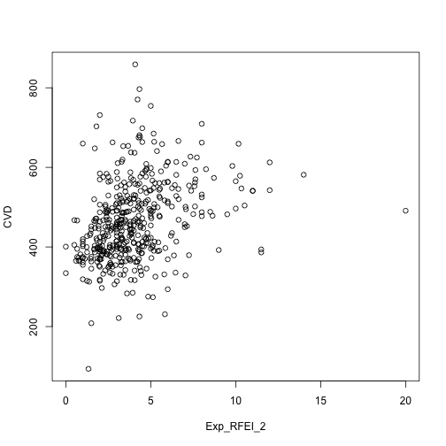

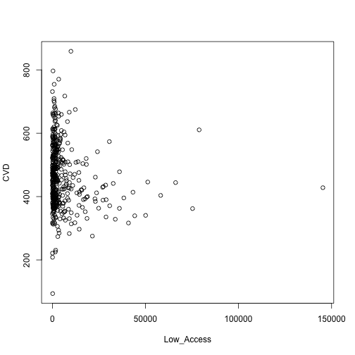

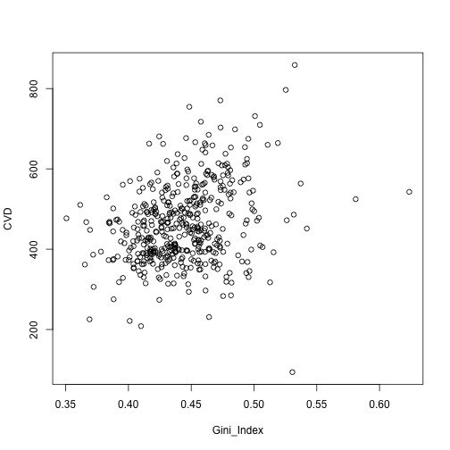

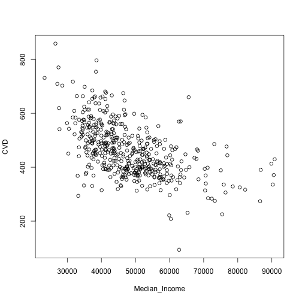

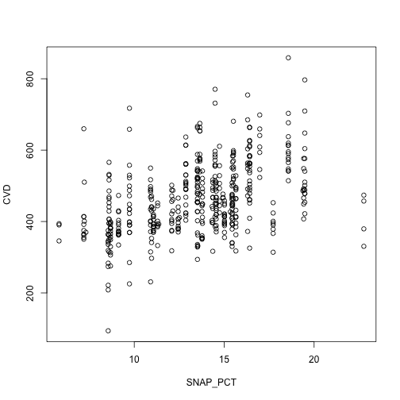